# Applied Multivariate Statistical Analysis

Exercise 2

Kasper Veje Jakobsen (kasja20@student.sdu.dk)

2025-04-23

# Exercise 1.4

This exercise uses data on the world’s 10 largest companies, including sales, profits, and assets (in billions).

## Part (a)

Plot the scatter diagram and marginal dot diagrams for variables x1 (sales) and x2 (profits), then comment on the appearance of the diagrams.

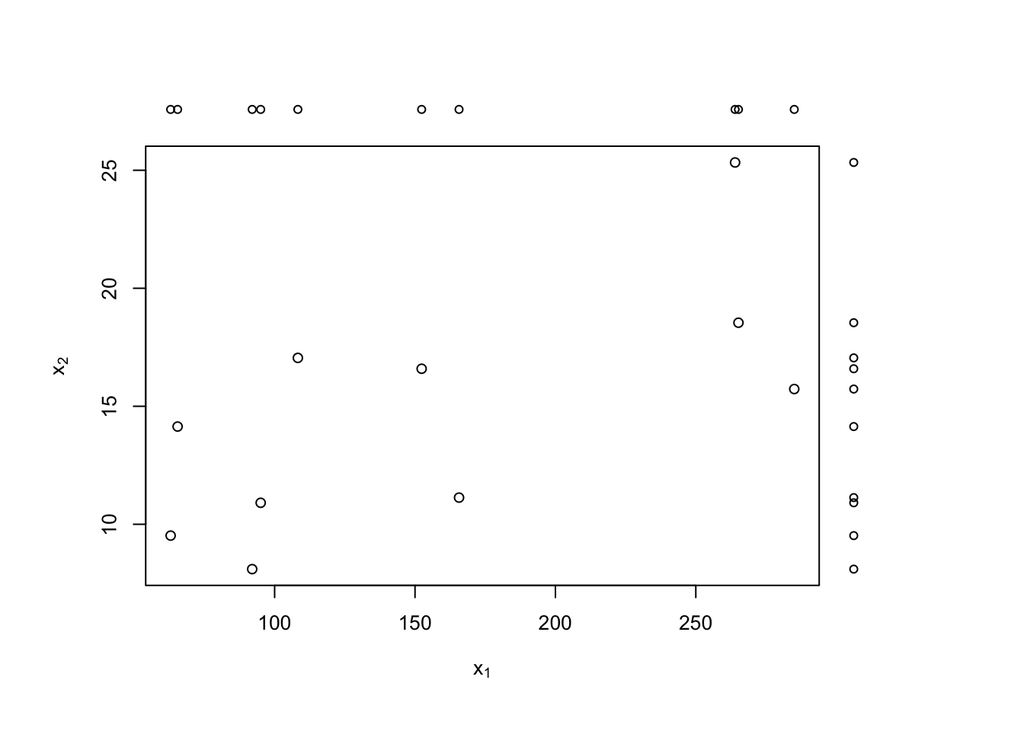

```r
# Load the Forbes data
data("P1-4")

# Create a scatterplot with a marginal dot plot for the variables x1 and x2
marginal.dot.plot(tbl$V1, tbl$V2, xlab = expression("x"[1]), ylab = expression("x"[2]))
```

The scatter plot shows a positive relationship between sales and profits. Companies with higher sales tend to have higher profits. The marginal dot plots show the distribution of each variable, with some companies having notably higher sales and profits than others.

## Part (b)

Compute the mean of x1 and x2, variances s11 and s22, covariance s12, and correlation coefficient r12. Then interpret r12.

```r
# Mean of x1
mean(tbl$V1)
```

```
## [1] 155.603
```

```r
# Mean of x2
mean(tbl$V2)
```

```
## [1] 14.704
```

```r
# Variance of x1 (using n divisor)
var(tbl$V1) * (nrow(tbl) - 1) / nrow(tbl)
```

```
## [1] 6728.808
```

```r
# Variance of x2 (using n divisor)
var(tbl$V2) * (nrow(tbl) - 1) / nrow(tbl)
```

```
## [1] 23.57128
```

```r
# Covariance between x1 and x2 (using n divisor)
cov(tbl$V1, tbl$V2) * (nrow(tbl) - 1) / nrow(tbl)
```

```
## [1] 273.2568
```

```r
# Correlation between x1 and x2
cor(tbl$V1, tbl$V2)
```

```
## [1] 0.686136
```

**Interpretation of r12:**

The correlation coefficient r12 is approximately 0.69, indicating a strong positive linear relationship between sales and profits. This means that companies with higher sales tend to have higher profits.

# Exercise 1.5

Use the data in Exercise 1.4 to complete the following tasks.

## Part (a)

Plot the scatter diagrams and dot diagrams for (x2, x3) and (x1, x3), then comment on the patterns.

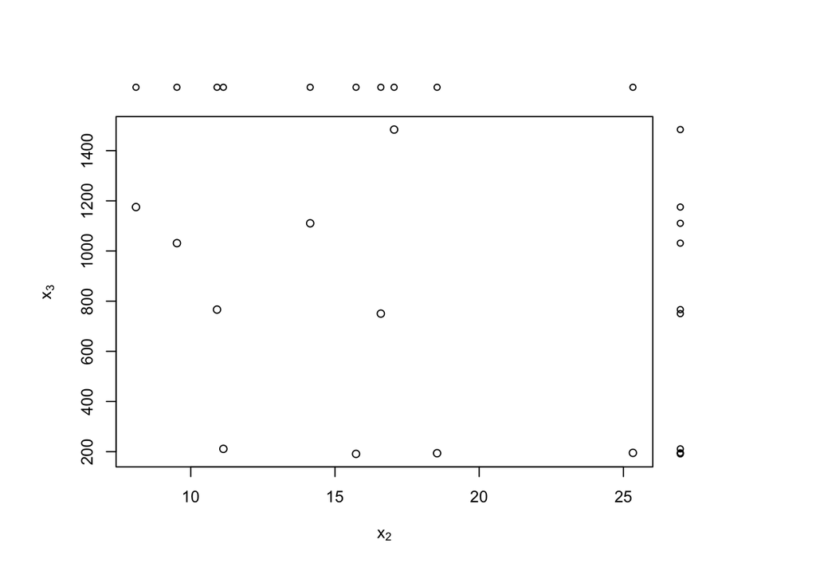

```r
# Load Forbes data
data("P1-4")

# Create a scatterplot with a marginal dot plot for the variables x2 and x3
marginal.dot.plot(tbl$V2, tbl$V3, xlab = expression("x"[2]), ylab = expression("x"[3]))
```

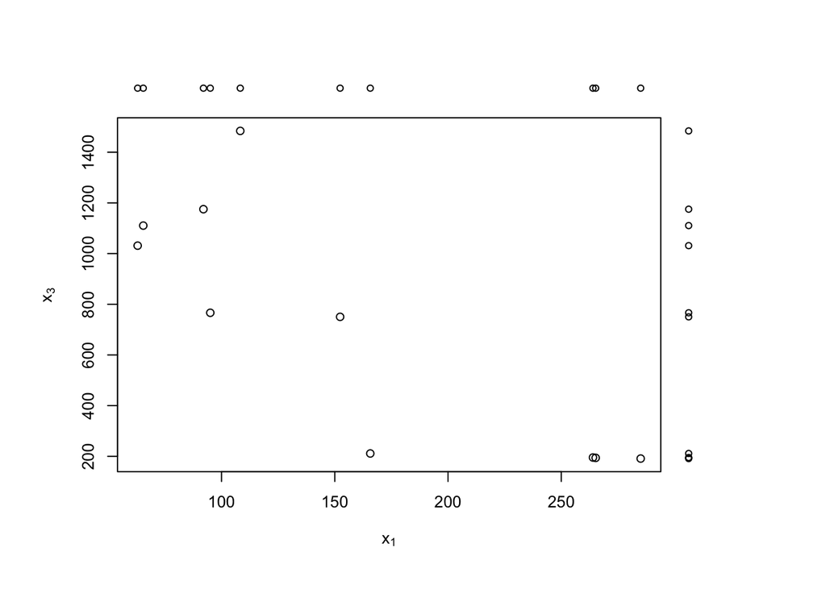

```r
# Create a scatterplot with a marginal dot plot for the variables x1 and x3
marginal.dot.plot(tbl$V1, tbl$V3, xlab = expression("x"[1]), ylab = expression("x"[3]))
```

**Comments on the patterns:**

1. For (x2, x3) - Profits vs. Assets:
   - There is no clear linear relationship between profits and assets.
2. For (x1, x3) - Sales vs. Assets:
   - There seem to be a negative relationship between sales and assets.

## Part (b)

Compute the x̄, Sn, and R arrays for (x1, x2, x3).

```r
# Mean vector
cat("Mean vector:\n")
```

```
## Mean vector:
```

```r
print(round(colMeans(tbl),2))
```

```
##     V1     V2     V3
## 155.60  14.70 710.91
```

```r
# Variance-covariance matrix (using n divisor)
cat("\nVariance-covariance matrix:\n")
```

```
##
## Variance-covariance matrix:
```

```r
print(round(cov(tbl) * (nrow(tbl) - 1) / nrow(tbl)),2)
```

```
##        V1   V2     V3
## V1   6729  273 -32018
## V2    273   24   -948
## V3 -32018 -948 213349
```

```r
# Correlation matrix
cat("\nCorrelation matrix:\n")
```

```
##
## Correlation matrix:
```

```r
print(cor(tbl))
```

```
##            V1         V2         V3
## V1  1.0000000  0.6861360 -0.8450549
## V2  0.6861360  1.0000000 -0.4229366
## V3 -0.8450549 -0.4229366  1.0000000
```

# Exercise 1.8

This exercise asks us to calculate distances between points using different distance formulas.

Evaluate the distance of the point P = (-1, -1) to the point Q = (1, 0) using: - The Euclidean distance formula with p = 2 - The statistical distance with a11 = 1/3, a22 = 4/27, and a12 = 1/9

```r
# Calculate the Euclidean distance
euclid_distance <- sqrt((-1 - 1)^2 + (-1 - 0)^2)
print(euclid_distance)
```

```
## [1] 2.236068
```

```r
# Calculate the statistical distance
stat_distance <- sqrt(1/3 * (-1 - 1)^2 + 2/9 * (-1 - 1) * (-1 - 0) + 4/27 * (-1 - 0)^2)
print(stat_distance)
```

```
## [1] 1.387777
```

# Exercise 1.14

This exercise uses data related to multiple sclerosis (MS) responses to visual stimuli.

## Part (a)

Plot the two-dimensional scatter diagram for the variables X2 (total response to stimulus S1) and X4 (total response to stimulus S2) for the multiple-sclerosis group.

```r
rm(list=ls())
# Load multiple-sclerosis data
data("T1-6")

# Inspect data
str(tbl)
```

```
## 'data.frame':    98 obs. of  6 variables:
##  $ V1: int  18 19 20 20 20 21 21 21 22 22 ...
##  $ V2: num  152 138 144 144 149 ...
##  $ V3: num  1.6 0.4 0 3.2 0 0.8 1.6 1.6 3.2 0 ...
##  $ V4: num  198 181 186 195 218 ...
##  $ V5: num  0 1.6 0.8 0 0 0.8 0.8 3.2 3.2 0.2 ...
##  $ V6: int  0 0 0 0 0 0 0 0 0 0 ...
```

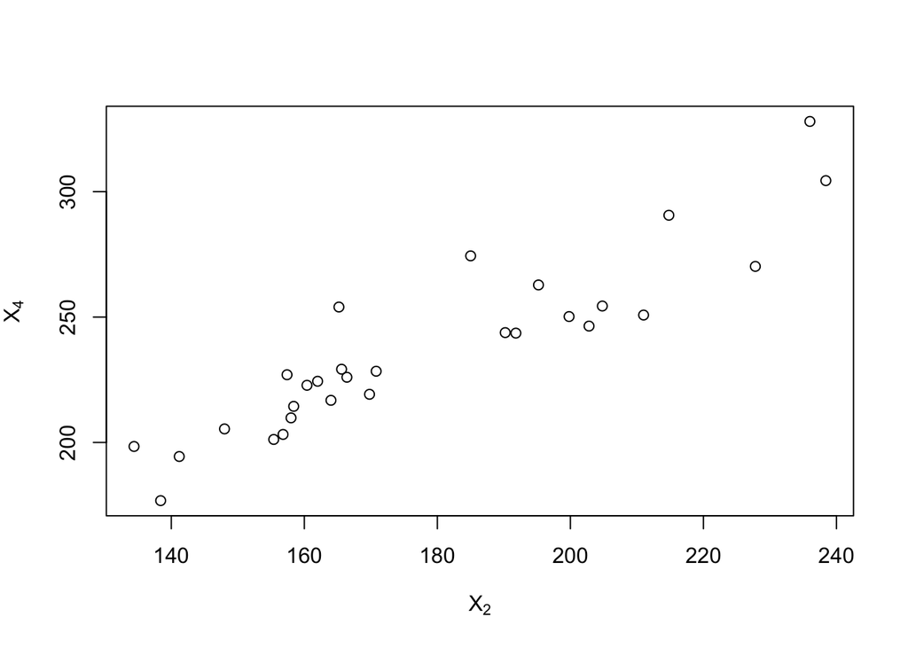

```r
# Extract MS group data
ms <- subset(tbl, V6 == 1)

# Scatterplot of X4 versus X2
plot(ms$V2, ms$V4, xlab = expression("X"[2]), ylab = expression("X"[4]))
```

**Comments on the diagram:**

The scatter plot shows a strong positive relationship between responses to stimulus S1 (X2) and stimulus S2 (X4) in the MS group. Patients who have a higher response to S1 also tend to have a higher response to S2.

## Part (b)

Compute the x̄, Sn, and R arrays for the non-multiple-sclerosis and multiple-sclerosis groups separately.

```r
# Separate non-MS group and MS group
nms <- subset(tbl, V6 == 0)

# Non-MS group statistics
cat("Non-MS Group - Mean vector:\n")
```

```
## Non-MS Group - Mean vector:
```

```r
print(colMeans(nms[1:5]))
```

```
##         V1         V2         V3         V4         V5
##  37.985507 147.289855   1.562319 195.602899   1.620290
```

```r
cat("\nNon-MS Group - Variance-covariance matrix:\n")
```

```
##
## Non-MS Group - Variance-covariance matrix:
```

```r
print(cov(nms[1:5]) * (nrow(nms[1:5]) - 1) / nrow(nms[1:5]))
```

```
##            V1         V2        V3         V4        V5
## V1 273.608486  94.015795 5.2835119 102.220332 3.1944970
## V2  94.015795 110.667288 1.7407771 105.237421 2.0126696
## V3   5.283512   1.740777 1.7788700   2.202428 0.4940979
## V4 102.220332 105.237421 2.2024281 182.544339 2.3170426
## V5   3.194497   2.012670 0.4940979   2.317043 2.3213275
```

```r
cat("\nNon-MS Group - Correlation matrix:\n")
```

```
##
## Non-MS Group - Correlation matrix:
```

```r
print(cor(nms[1:5]))
```

```
##           V1        V2        V3        V4        V5
## V1 1.0000000 0.5402894 0.2394891 0.4573917 0.1267563
## V2 0.5402894 1.0000000 0.1240685 0.7404170 0.1255725
## V3 0.2394891 0.1240685 1.0000000 0.1222209 0.2431491
## V4 0.4573917 0.7404170 0.1222209 1.0000000 0.1125594
## V5 0.1267563 0.1255725 0.2431491 0.1125594 1.0000000
```

```r
# MS group statistics
cat("\nMS Group - Mean vector:\n")
```

```
##
## MS Group - Mean vector:
```

```r
print(colMeans(ms[1:5]))
```

```
##        V1        V2        V3        V4        V5
##  42.06897 178.26897  12.27586 236.93103  13.08276
```

```r
cat("\nMS Group - Variance-covariance matrix:\n")
```

```
##
## MS Group - Variance-covariance matrix:
```

```r
print(cov(ms[1:5]) * (nrow(ms[1:5]) - 1) / nrow(ms[1:5]))
```

```
##           V1        V2        V3         V4        V5
## V1 116.96076  50.97455 -19.52247   65.78407 -28.79191
## V2  50.97455 815.55386 236.03339  880.95234 103.08257
## V3 -19.52247 236.03339 306.32390  224.35282 287.06683
## V4  65.78407 880.95234 224.35282 1139.34145  78.30088
## V5 -28.79191 103.08257 287.06683   78.30088 338.94212
```

```r
cat("\nMS Group - Correlation matrix:\n")
```

```
##
## MS Group - Correlation matrix:
```

```r
print(cor(ms[1:5]))
```

```
##            V1        V2         V3        V4         V5
## V1  1.0000000 0.1650468 -0.1031393 0.1802078 -0.1446065
## V2  0.1650468 1.0000000  0.4722334 0.9139010  0.1960632
## V3 -0.1031393 0.4722334  1.0000000 0.3797643  0.8909017
## V4  0.1802078 0.9139010  0.3797643 1.0000000  0.1260019
## V5 -0.1446065 0.1960632  0.8909017 0.1260019  1.0000000
```

# Exercise 1.17

This exercise involves analyzing national track records for women across different countries.

```r
# Clean
rm(list=ls())

# Load national-track-records data
data("T1-9")
ntr <- tbl

# Add column names
colnames(ntr) <- c("Country", "100m", "200m", "400m", "800m", "1500m", "3000m", "Marathon")

# Calculate in minutes
ntr$`100m` <- ntr$`100m` / 60
ntr$`200m` <- ntr$`200m` / 60
ntr$`400m` <- ntr$`400m` / 60

# Calculate mean vector
print(colMeans(ntr[2:8]))
```

```
##        100m        200m        400m        800m       1500m       3000m
##   0.1892963   0.3853086   0.8664846   2.0224074   4.1894444   9.0807407
##    Marathon
## 153.6192593
```

```r
# Calculate variance-covariance matrix
print(cov(ntr[2:8]) * (nrow(ntr[2:8]) - 1) / nrow(ntr[2:8]))
```

```
##                  100m         200m         400m         800m       1500m
## 100m     4.234431e-05 0.0000939389 0.0002429974 0.0004531756 0.001372294
## 200m     9.393890e-05 0.0002353070 0.0005978412 0.0010823434 0.003316807
## 400m     2.429974e-04 0.0005978412 0.0018390394 0.0029740186 0.008329127
## 800m     4.531756e-04 0.0010823434 0.0029740186 0.0074071674 0.021018004
## 1500m    1.372294e-03 0.0033168073 0.0083291272 0.0210180041 0.072808951
## 3000m    3.825861e-03 0.0090680738 0.0233398880 0.0602426612 0.212152263
## Marathon 7.089858e-02 0.1698778829 0.4728079515 1.1970684499 3.474284774
##                 3000m     Marathon
## 100m      0.003825861   0.07089858
## 200m      0.009068074   0.16987788
## 400m      0.023339888   0.47280795
## 800m      0.060242661   1.19706845
## 1500m     0.212152263   3.47428477
## 3000m     0.652447599  10.50783018
## Marathon 10.507830178 265.26514760
```

```r
# Calculate correlation matrix
print(cor(ntr[2:8]))
```

```
##               100m      200m      400m      800m     1500m     3000m  Marathon
## 100m     1.0000000 0.9410886 0.8707802 0.8091758 0.7815510 0.7278784 0.6689597
## 200m     0.9410886 1.0000000 0.9088096 0.8198258 0.8013282 0.7318546 0.6799537
## 400m     0.8707802 0.9088096 1.0000000 0.8057904 0.7197996 0.6737991 0.6769384
## 800m     0.8091758 0.8198258 0.8057904 1.0000000 0.9050509 0.8665732 0.8539900
## 1500m    0.7815510 0.8013282 0.7197996 0.9050509 1.0000000 0.9733801 0.7905565
## 3000m    0.7278784 0.7318546 0.6737991 0.8665732 0.9733801 1.0000000 0.7987302
## Marathon 0.6689597 0.6799537 0.6769384 0.8539900 0.7905565 0.7987302 1.0000000
```

# Exercise 1.18

Convert the national track records for women to speeds measured in meters per second, then compute the x̄, Sn, and R arrays.

```r
# Convert times to speeds
data("T1-9")
speed_tbl <- tbl
colnames(speed_tbl) <- c("Country", "100m", "200m", "400m", "800m", "1500m", "3000m", "Marathon")
print(cor(speed_tbl[2:8]))
```

```
##               100m      200m      400m      800m     1500m     3000m  Marathon
## 100m     1.0000000 0.9410886 0.8707802 0.8091758 0.7815510 0.7278784 0.6689597
## 200m     0.9410886 1.0000000 0.9088096 0.8198258 0.8013282 0.7318546 0.6799537
## 400m     0.8707802 0.9088096 1.0000000 0.8057904 0.7197996 0.6737991 0.6769384
## 800m     0.8091758 0.8198258 0.8057904 1.0000000 0.9050509 0.8665732 0.8539900
## 1500m    0.7815510 0.8013282 0.7197996 0.9050509 1.0000000 0.9733801 0.7905565
## 3000m    0.7278784 0.7318546 0.6737991 0.8665732 0.9733801 1.0000000 0.7987302
## Marathon 0.6689597 0.6799537 0.6769384 0.8539900 0.7905565 0.7987302 1.0000000
```

```r
speed_tbl$`100m` <- 100 / (speed_tbl$`100m`)  # 100m
speed_tbl$`200m` <- 200 / (speed_tbl$`200m`)  # 200m
speed_tbl$`400m` <- 400 / (speed_tbl$`400m`)  # 400m
speed_tbl$`800m` <- 800 / (speed_tbl$`800m` * 60)  # 800m
speed_tbl$`1500m` <- 1500 / (speed_tbl$`1500m` * 60)  # 1500m
speed_tbl$`3000m` <- 3000 / (speed_tbl$`3000m` * 60)  # 3000m
speed_tbl$`Marathon` <- 42195 / (speed_tbl$`Marathon` * 60)  # Marathon

print(cor(speed_tbl[2:8]))
```

```
##               100m      200m      400m      800m     1500m     3000m  Marathon
## 100m     1.0000000 0.9383028 0.8655248 0.7974687 0.7764777 0.7287297 0.6601124
## 200m     0.9383028 1.0000000 0.9058875 0.8159945 0.8057456 0.7409469 0.6748635
## 400m     0.8655248 0.9058875 1.0000000 0.8041737 0.7306437 0.6944025 0.6722005
## 800m     0.7974687 0.8159945 0.8041737 1.0000000 0.9060324 0.8754795 0.8518052
## 1500m    0.7764777 0.8057456 0.7306437 0.9060324 1.0000000 0.9718385 0.8244153
## 3000m    0.7287297 0.7409469 0.6944025 0.8754795 0.9718385 1.0000000 0.8541900
## Marathon 0.6601124 0.6748635 0.6722005 0.8518052 0.8244153 0.8541900 1.0000000
```

```r
# Calculate mean vector
print(colMeans(speed_tbl[2:8]))
```

```
##     100m     200m     400m     800m    1500m    3000m Marathon
## 8.814772 8.664408 7.712067 6.604214 5.989687 5.542701 4.620264
```

```r
# Calculate variance-covariance matrix
print(cov(speed_tbl[2:8]) * (nrow(speed_tbl[2:8]) - 1) / nrow(speed_tbl[2:8]))
```

```
##                100m       200m       400m       800m      1500m      3000m
## 100m     0.08886163 0.09383586 0.09488221 0.06385913 0.08069721 0.09043587
## 200m     0.09383586 0.11254789 0.11176120 0.07353737 0.09424082 0.10348392
## 400m     0.09488221 0.11176120 0.13523721 0.07944200 0.09367553 0.10631059
## 800m     0.06385913 0.07353737 0.07944200 0.07216131 0.08485322 0.09790735
## 1500m    0.08069721 0.09424082 0.09367553 0.08485322 0.12154716 0.14105343
## 3000m    0.09043587 0.10348392 0.10631059 0.09790735 0.14105343 0.17331425
## Marathon 0.07959802 0.09158236 0.09999405 0.09255923 0.11626411 0.14384635
##            Marathon
## 100m     0.07959802
## 200m     0.09158236
## 400m     0.09999405
## 800m     0.09255923
## 1500m    0.11626411
## 3000m    0.14384635
## Marathon 0.16362679
```

```r
# Calculate correlation matrix
print(cor(speed_tbl[2:8]))
```

```
##               100m      200m      400m      800m     1500m     3000m  Marathon
## 100m     1.0000000 0.9383028 0.8655248 0.7974687 0.7764777 0.7287297 0.6601124
## 200m     0.9383028 1.0000000 0.9058875 0.8159945 0.8057456 0.7409469 0.6748635
## 400m     0.8655248 0.9058875 1.0000000 0.8041737 0.7306437 0.6944025 0.6722005
## 800m     0.7974687 0.8159945 0.8041737 1.0000000 0.9060324 0.8754795 0.8518052
## 1500m    0.7764777 0.8057456 0.7306437 0.9060324 1.0000000 0.9718385 0.8244153
## 3000m    0.7287297 0.7409469 0.6944025 0.8754795 0.9718385 1.0000000 0.8541900
## Marathon 0.6601124 0.6748635 0.6722005 0.8518052 0.8244153 0.8541900 1.0000000
```

# Exercise 1.19

Create the scatter plot and boxplot displays for the mineral-content data and the national track records data.

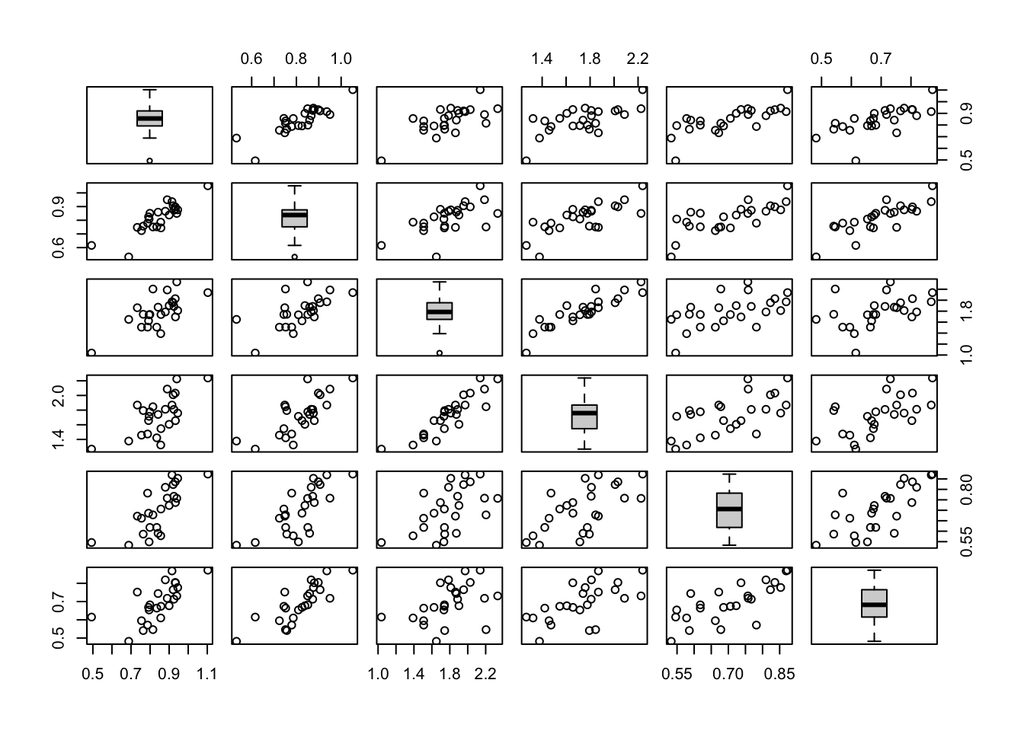

```r
# Load mineral content data
data("T1-8")

# Create a matrix of scatterplots with boxplots on the main diagonal
pairs(tbl, diag.panel = panel.boxplot, labels = "")
```

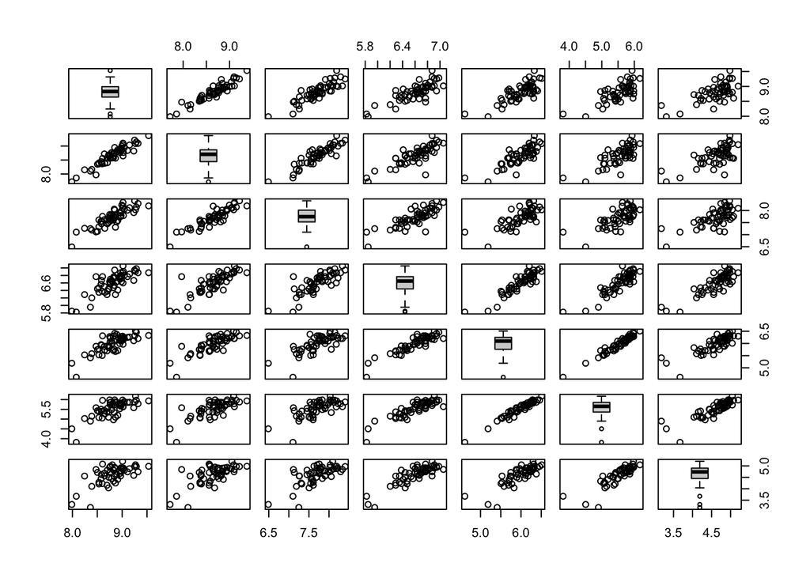

```r
# Create a matrix of scatterplots with boxplots on the main diagonal
pairs(speed_tbl[2:8], diag.panel = panel.boxplot, labels = "")
```

This matrix plot shows scatter plots of each pair of variables in the off-diagonal positions and boxplots of each variable on the diagonal. It allows us to examine relationships between different track events and the distribution of each variable.

# Exercise 1.27

This exercise explores the relationship between national park size and visitor numbers.

## Part (a)

Create a scatter plot and calculate the correlation coefficient.

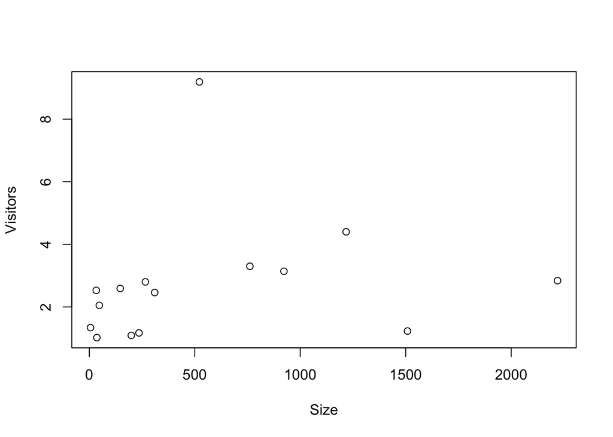

```r
rm(list=ls())
# Load national parks data
data("T1-11")

park <- tbl
colnames(park) <- c("size", "visitors")

# Scatterplot of visitors versus size
plot(park$size, park$visitors, xlab = "Size", ylab = "Visitors")
```

```r
# Calculate correlation coefficient
cat("Correlation coefficient:", cor(park$size, park$visitors), "\n")
```

```
## Correlation coefficient: 0.1725274
```

## Part (b)

Identify the park that is unusual, drop this point, and recalculate the correlation coefficient.

```r
# Remove Great Smoky (observation 7) from the data frame
park_filtered <- park[-7, ]

# Calculate correlation coefficient without Great Smoky
cat("Correlation coefficient without Great Smoky:", cor(park_filtered$size, park_filtered$visitors), "\n")
```

```
## Correlation coefficient without Great Smoky: 0.3907829
```

**Comments on the effect of this point:**

After removing Great Smoky Mountains National Park (observation 7), the correlation coefficient changes significantly. This demonstrates the sensitivity of correlation coefficients to outliers or influential observations.

## Part (c)

Would the correlation in Part b change if you measure size in square miles instead of acres?

```r
# Convert acres to square miles (1 acre = 1/640 square mile)
park$size_sqmiles <- park$size / 640
park_filtered$size_sqmiles <- park_filtered$size / 640

# Calculate correlation with square miles
cat("Correlation coefficient using square miles:", cor(park$size_sqmiles, park$visitors), "\n")
```

```
## Correlation coefficient using square miles: 0.1725274
```

```r
cat("Correlation coefficient without Great Smoky using square miles:",
    cor(park_filtered$size_sqmiles, park_filtered$visitors), "\n")
```

```
## Correlation coefficient without Great Smoky using square miles: 0.3907829
```

The correlation coefficients remain exactly the same when we change the unit of measurement from acres to square miles. This is because correlation is calculated based on standardized values (z-scores), which removes the effect of the scale of measurement. Linear transformations preserve the correlation coefficient.